# Lectura 11

John Serrano y Nícolas Farfán

2022-11-06

### **Alternativas robustas para la media**

La media truncada se calcula descartando un determinado porcentaje (γ) de los valores en ambos extremos (colas) de la distribución.

En R, podemos calcular la media truncada mediante la ya conocida función mean() del paquete base, agregando el argumento adicional trim con la proporción γ de los datos extremos a descartar, esto es **mean(x, trim = 0.2)** para un ejemplo donde se quiere truncar el 20% de los datos a cada extremo.

Otra opción puede ser, en lugar de descartar los valores extremos en cada cola, reemplazarlos por los valores extremos que no serían descartados al usar la media truncada y luego calcular la media con la muestra modificada. A esta medida se le conoce como **media Winsorizada**

En R, podemos hacer este cálculo mediante la función **winmean(x, tr)** del paquete **WRS2**, donde:

- x: vector con la muestra original.
- tr: proporción de los datos en cada cola a Winsorizar.

### **Prueba de Yuen para dos muestras independientes**

La prueba de Yuen es una buena alternativa a la prueba t de Student para muestras independientes cuando las varianzas de ambas muestras son muy diferentes o los tamaños de las muestras son muy dispares. Utiliza las medias truncadas y las medias Winsorizadas, aunque no se recomienda usar esta prueba si las muestras se truncan cerca del nivel de medianas (γ ≈ 0, 5).

Denotando como $\mu_{ti}$ a las medias truncadas de las poblaciones que dan origen a cada muestra trabajada, entonces:

- $H0: \mu_{t1} = \mu_{t2}$
- $HA: \mu_{t1} \neq \mu_{t2}$

En R, podemos aplicar la prueba de Yuen para muestras independientes mediante la función **yuen(formula, data, tr)** del paquete **WRS2**, donde:

- formula: tiene la forma < variable dependiente > ∼ < variable independiente >. La variable independiente debe tener dos niveles, a fin de determinar a qué muestra pertenece cada observación de la variable dependiente.
- data: matriz de datos.
- tr: parámetro γ de la poda.

Para pruebas unilaterales, sin embargo, se recomienda usar la variante que usa técnicas de remuestreo, implementada en la función **yuen(formula, data, tr, nboot)**, donde nboot señala la cantidad de submuestras a obtener mediante bootstrapping.

##### **Ejemplo para la prueba de Yenn:**

Se desea comparar el tiempo promedio de ejecución (en milisegundos) de dos algoritmos. Se han seleccionado aleatoriamente 70 instancias de igual tamaño del problema, las cuales han sido asignadas al azar a cada uno de los algoritmos. En consecuencia, contamos con $n_a = 40$ observaciones para el algoritmo A y $n_b = 30$ observaciones para el algoritmo B. Se ha establecido para este estudio un nivel de significación $\alpha = 0,05$.

**Prueba de Yuen para dos muestras independientes**

```r
library ( WRS2 )
library ( ggpubr )
```

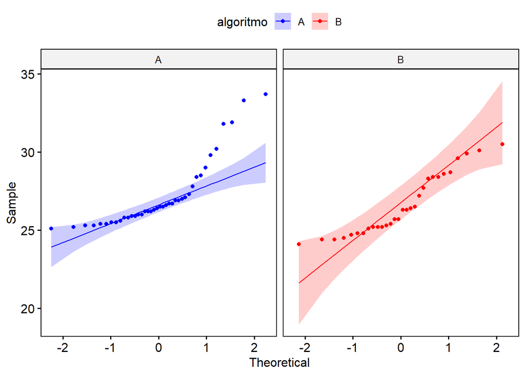

```r
# Construir data frame .
a <- c (25.1 , 25.2 , 25.3 , 25.3 , 25.4 , 25.4 , 25.5 , 25.5 , 25.6 , 25.8 , 25.8 ,
        25.9 , 25.9 , 26.0 , 26.0 , 26.2 , 26.2 , 26.2 , 26.3 , 26.4 , 26.5 , 26.5 ,
        26.6 , 26.7 , 26.7 , 26.9 , 26.9 , 27.0 , 27.1 , 27.3 , 27.8 , 28.4 , 28.5 ,
        29.0 , 29.8 , 30.2 , 31.8 , 31.9 , 33.3 , 33.7)

b <- c (24.1 , 24.4 , 24.4 , 24.5 , 24.7 , 24.8 , 24.8 , 25.1 , 25.2 , 25.2 , 25.2 ,
        25.3 , 25.4 , 25.7 , 25.7 , 26.3 , 26.3 , 26.4 , 26.5 , 27.2 , 27.7 , 28.3 ,
        28.4 , 28.4 , 28.6 , 28.7 , 29.6 , 29.9 , 30.1 , 30.5)

tiempo <- c(a,b)
algoritmo <- c(rep("A", length (a)) , rep("B",length(b)))
datos <- data.frame(tiempo, algoritmo)

# Comprobar normalidad .
g <- ggqqplot (datos, x = "tiempo", facet.by = "algoritmo",
               palette = c("blue", "red") , color = "algoritmo")

print(g)
```

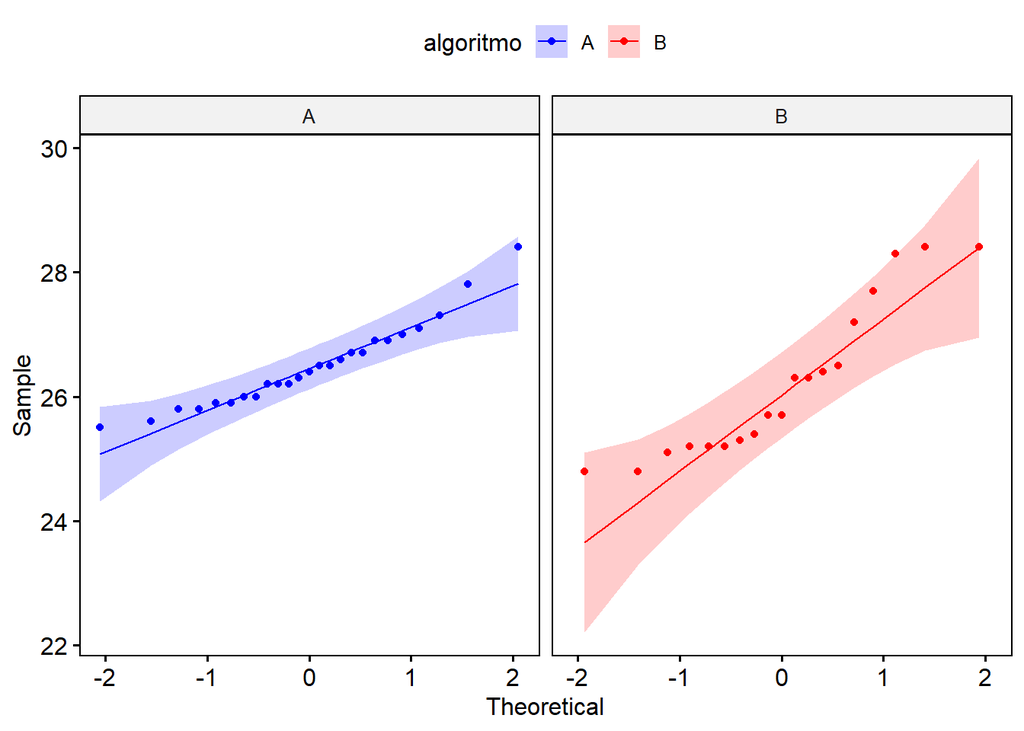

```r
# Establecer nivel de significaci ón.
alfa <- 0.05

# Ver poda del 20 %.
gamma <- 0.2
n_a <- length(a)
n_b <- length(b)

poda_a <- n_a * gamma
poda_b <- n_b * gamma

a_truncada <- a [poda_a:(n_a - poda_a)]
b_truncada <- b [poda_b:(n_b - poda_b)]
tiempo <- c(a_truncada, b_truncada)
algoritmo <- c(rep("A", length (a_truncada)) , rep("B", length (b_truncada)))
datos_truncados <- data.frame (tiempo,algoritmo)

g <- ggqqplot (datos_truncados , x = "tiempo", facet.by = "algoritmo",
               palette = c("blue", "red") , color = "algoritmo")

print(g)
```

```r
# Aplicar prueba de Yuen .
prueba <- yuen(tiempo~algoritmo, data = datos , tr = gamma)
print(prueba)
```

```
## Call:
## yuen(formula = tiempo ~ algoritmo, data = datos, tr = gamma)
##
## Test statistic: 0.455 (df = 29.05), p-value = 0.65252
##
## Trimmed mean difference:  0.24583
## 95 percent confidence interval:
## -0.8592     1.3509
##
## Explanatory measure of effect size: 0.1
```

El paquete **WRS2** incluye también la función **pb2gen(formula, data, est, nboot)**, que usa remuestreo con bootstrapping para aplicar la prueba de Yuen usando otras medidas robustas de tendencia central, donde:

- formula: tiene la misma forma descrita para la prueba de Yuen.
- data: matriz de datos.
- est: medida a emplear. Puede tomar las opciones “mean” para la media y “median” (mediana), entre otras opciones que escapan a los alcances de este curso.
- nboot: cantidad de muestras a generar mediante bootstrapping.

**Prueba de Yuen con bootstrapping para dos muestras independientes usando la media y la mediana**

```r
library (WRS2)
# Construir data frame .
a <- c (25.1 , 25.2 , 25.3 , 25.3 , 25.4 , 25.4 , 25.5 , 25.5 , 25.6 , 25.8 , 25.8 ,
        25.9 , 25.9 , 26.0 , 26.0 , 26.2 , 26.2 , 26.2 , 26.3 , 26.4 , 26.5 , 26.5 ,
        26.6 , 26.7 , 26.7 , 26.9 , 26.9 , 27.0 , 27.1 , 27.3 , 27.8 , 28.4 , 28.5 ,
        29.0 , 29.8 , 30.2 , 31.8 , 31.9 , 33.3 , 33.7)

b <- c (24.1 , 24.4 , 24.4 , 24.5 , 24.7 , 24.8 , 24.8 , 25.1 , 25.2 , 25.2 , 25.2 ,
        25.3 , 25.4 , 25.7 , 25.7 , 26.3 , 26.3 , 26.4 , 26.5 , 27.2 , 27.7 , 28.3 ,
        28.4 , 28.4 , 28.6 , 28.7 , 29.6 , 29.9 , 30.1 , 30.5)

tiempo <- c(a,b)
algoritmo <- c(rep("A",length(a)), rep("B", length(b)))
datos <- data.frame(tiempo, algoritmo)

# Establecer nivel de significación y cantidad de muestras a generar
# con bootstrapping .
alfa <- 0.05
bootstrap <- 999

# Aplicar prueba con la media
set.seed(135)

prueba_media <- pb2gen(tiempo~algoritmo,
                       data = datos,
                       est = "mean",
                       nboot = bootstrap)

cat("Resultado al usar la media como estimador")
```

```
## Resultado al usar la media como estimador
```

```r
print(prueba_media)
```

```
## Call:
## pb2gen(formula = tiempo ~ algoritmo, data = datos, est = "mean",
##     nboot = bootstrap)
##
## Test statistic: 0.61, p-value = 0.21321
## 95% confidence interval:
## -0.3008    1.5617
```

```r
# Aplicar prueba con la mediana
set.seed(135)

prueba_mediana <- pb2gen(tiempo~algoritmo,
                         data = datos,
                         est = "median",
                         nboot = bootstrap)

cat("Resultado al usar la mediana como estimado")
```

```
## Resultado al usar la mediana como estimado
```

```r
print(prueba_mediana)
```

```
## Call:
## pb2gen(formula = tiempo ~ algoritmo, data = datos, est = "median",
##     nboot = bootstrap)
##
## Test statistic: 0.45, p-value = 0.47147
## 95% confidence interval:
## -0.95    1.35
```

### **Prueba de Yuen para dos muestras pareadas**

Supongamos ahora que queremos comparar el rendimiento de dos algoritmos X e Y, para lo cual hemos seleccionado aleatoriamente 25 instancias del problema y registrado su tiempo de ejecución en milisegundos con cada uno de los algoritmos. El script ilustra el uso de la función **yuend(x, y, tr)** del paquete **WRS2**, que compara las medias truncadas.

**Prueba de Yuen para dos muestras pareadas.**

```r
library (WRS2)
# Construir data frame .
x <- c (32.0 , 32.0 , 32.0 , 32.0 , 32.1 , 32.1 , 32.1 , 32.2 , 32.3 , 32.3 , 32.5 ,
        32.7 , 32.7 , 32.7 , 33.1 , 33.4 , 33.9 , 34.1 , 34.2 , 34.5 , 36.0 , 36.6 ,
        36.7 , 37.2 , 38.0)
y <- c (33.0 , 33.0 , 33.0 , 33.0 , 33.0 , 33.0 , 33.3 , 33.3 , 33.3 , 33.3 , 33.5 ,
        33.6 , 33.7 , 33.9 , 33.9 , 34.2 , 34.2 , 34.3 , 34.3 , 34.4 , 34.5 , 34.6 ,
        36.4 , 38.9 , 40.2)

# Fijar nivel de significación.
alfa <- 0.05

# Aplicar prueba de Yuen para muestras pareadas .
gamma <- 0.2
prueba <- yuend (x = x, y = y, tr = gamma)
print (prueba)
```

```
## Call:
## yuend(x = x, y = y, tr = gamma)
##
## Test statistic: -4.5915 (df = 14), p-value = 0.00042
##
## Trimmed mean difference:  -0.76
## 95 percent confidence interval:
## -1.115     -0.405
##
## Explanatory measure of effect size: 0.44
```

Puesto que el valor p obtenido, p < 0, 001, es menor que el nivel de significación, la evidencia es suficientemente fuerte como para rechazar la hipótesis nula en favor de la hipótesis alternativa. En consecuencia, podemos afirmar con 95 % de confianza que existe una diferencia estadísticamente significativa en el desempeño de ambos algoritmos, siendo el algoritmo X el más eficiente (puesto que la diferencia estimada entre las medias tiene signo negativo)

### **Comparaciones de una vía para múltiples grupos independientes**

WRS2 ofrece diferentes alternativas a ANOVA de una vía para muestras independientes que podemos usar cuando los tamaños muestrales son muy diferentes o no se cumple la condición de homocedasticidad.

La función **t1way(formula, data, tr, alpha)** efectúa un procedimiento similar a ANOVA usando medias truncadas. A su vez, la función lincon(formula, data, tr, alpha) permite realizar el procedimiento posthoc correspondiente.

De manera similar, **t1waybt(formula, data, tr, nboot)** realiza un procedimiento análogo al anterior incorporando remuestreo con bootstrapping. En este caso, el procedimiento post-hoc puede realizarse mediante la función **mcppb20(formula, data, tr, nboot)**.

Una tercera opción es la función **med1way(formula, data, iter)**, que emplea la mediana y sigue un proceso iterativo. No obstante, en este caso el paquete no ofrece funciones que permitan realizar el procedimiento post-hoc.

Los argumentos asociados a las funciones mencionadas en los párrafos anteriores son:

- formula: de la forma < variable dependiente > ∼ < variable independiente >.
- data: matriz de datos.
- tr: parámetro γ de la poda.
- alpha: nivel de significación.
- nboot: cantidad de muestras a generar mediante bootstrapping.
- iter: cantidad de iteraciones a realizar.

##### **Ejemplo para las funciones anteriores:**

Deseamos comparar el tiempo promedio de ejecución (en milisegundos) de tres algoritmos, contando con $n_{a} = 40$ observaciones para el algoritmo A, $n_b = 30$ observaciones para el algoritmo B y $n_c = 35$ observaciones para el algoritmo C. Se ha establecido para este estudio un nivel de significación $\alpha = 0,05$.

**Alternativas robustas para comparar entre múltiples grupos independientes**

```r
library ( WRS2 )

# Construir data frame .
a <- c(25.1 , 25.2 , 25.3 , 25.3 , 25.4 , 25.4 , 25.5 , 25.5 , 25.6 , 25.8 , 25.8 ,
        25.9 , 25.9 , 26.0 , 26.0 , 26.2 , 26.2 , 26.2 , 26.3 , 26.4 , 26.5 , 26.5 ,
        26.6 , 26.7 , 26.7 , 26.9 , 26.9 , 27.0 , 27.1 , 27.3 , 27.8 , 28.4 , 28.5 ,
        29.0 , 29.8 , 30.2 , 31.8 , 31.9 , 33.3 , 33.7)

b <- c(24.1 , 24.4 , 24.4 , 24.5 , 24.7 , 24.8 , 24.8 , 25.1 , 25.2 , 25.2 , 25.2 ,
        25.3 , 25.4 , 25.7 , 25.7 , 26.3 , 26.3 , 26.4 , 26.5 , 27.2 , 27.7 , 28.3 ,
        28.4 , 28.4 , 28.6 , 28.7 , 29.6 , 29.9 , 30.1 , 30.5)

c <- c(24.5 , 24.5 , 24.5 , 24.5 , 24.5 , 24.5 , 24.6 , 24.6 , 24.6 , 24.6 , 24.6 ,
        24.6 , 24.7 , 24.7 , 24.7 , 24.7 , 24.8 , 25.0 , 25.0 , 25.0 , 25.2 , 25.2 ,
        25.2 , 25.2 , 25.5 , 25.7 , 25.9 , 26.2 , 26.5 , 26.5 , 26.7 , 27.0 , 29.2 ,
        29.9 , 30.1)

tiempo <- c(a , b , c)
algoritmo <- c(rep("A", length ( a ) ) , rep("B", length ( b ) ) , rep ("C", length (c) ) )
datos <- data.frame (tiempo, algoritmo)

# Fijar nivel de significaci ón.
alfa <- 0.05

# Comparar los diferentes algoritmos usando medias truncadas .
cat ("Comparación entre grupos usando medias truncadas")
```

```
## Comparación entre grupos usando medias truncadas
```

```r
gamma <- 0.2

set.seed (666)

medias_truncadas <- t1way (tiempo~algoritmo, data = datos, tr = gamma, alpha = alfa )

print(medias_truncadas)
```

```
## Call:
## t1way(formula = tiempo ~ algoritmo, data = datos, tr = gamma,
##     alpha = alfa)
##
## Test statistic: F = 10.9813
## Degrees of freedom 1: 2
## Degrees of freedom 2: 34.39
## p-value: 0.00021
##
## Explanatory measure of effect size: 0.48
## Bootstrap CI: [0.28; 0.68]
```

```r
if(medias_truncadas$p.value < alfa){
  cat ("Procedimiento post - hoc")
  set.seed(666)
  post_hoc <- lincon(tiempo~algoritmo, data = datos , tr = gamma,
                     alpha = alfa )
  print(post_hoc)
}
```

```
## Procedimiento post - hocCall:
## lincon(formula = tiempo ~ algoritmo, data = datos, tr = gamma,
##     alpha = alfa)
##
##          psihat ci.lower ci.upper p.value
## A vs. B 0.24583 -1.11867  1.61033 0.65252
## A vs. C 1.49583  0.65571  2.33596 0.00022
## B vs. C 1.25000 -0.02757  2.52757 0.03909
```

```r
# Comparar los diferentes algoritmos usando bootstrap .
cat ("Comparación entre grupos usando bootstrap")
```

```
## Comparación entre grupos usando bootstrap
```

```r
muestras <- 999

set.seed(666)
bootstrap <- t1waybt(tiempo~algoritmo, data = datos, tr = gamma,
                     nboot = muestras)

print (medias_truncadas)
```

```
## Call:
## t1way(formula = tiempo ~ algoritmo, data = datos, tr = gamma,
##     alpha = alfa)
##
## Test statistic: F = 10.9813
## Degrees of freedom 1: 2
## Degrees of freedom 2: 34.39
## p-value: 0.00021
##
## Explanatory measure of effect size: 0.48
## Bootstrap CI: [0.28; 0.68]
```

```r
if(medias_truncadas$p.value < alfa){
  cat("Procedimiento post - hoc")
  set.seed(666)
  post_hoc <- mcppb20 (tiempo~algoritmo, data = datos , tr = gamma,
                       nboot = muestras )
  print(post_hoc)
}
```

```
## Procedimiento post - hocCall:
## mcppb20(formula = tiempo ~ algoritmo, data = datos, tr = gamma,
##     nboot = muestras)
##
##          psihat ci.lower ci.upper p-value
## A vs. B 0.24583 -0.91667  1.61389 0.55656
## A vs. C 1.49583  0.73690  2.44464 0.00000
## B vs. C 1.25000  0.16270  2.34206 0.00801
```

### **Comparaciones de una vía para múltiples grupos relacionados**

WRS2 también ofrece opciones robustas para reemplazar el procedimiento ANOVA de una vía para muestras correlacionadas, que podemos usar cuando los datos disponibles violan la condición de esfericidad.

La función **rmanova(y, groups, blocks, tr)** efectúa un procedimiento similar a ANOVA usando medias truncadas, mientras que la función **rmmcp(y, groups, blocks, tr, alpha)** implementa el procedimiento post-hoc para dicha prueba. Por otra parte, **rmanovab(y, groups, blocks, tr, nboot)** realiza la misma tarea que **rmanova()**, incorporando remuestreo con bootstrapping. En este caso, el procedimiento post-hoc está dado por la función **pairdepb(y, groups, blocks, tr, nboot)**. Los argumentos para esta familia de funciones son:

- formula: de la forma < variable dependiente > ∼ < variable independiente > .
- y: vector con la variable dependiente.
- groups: vector que indica los grupos.
- blocks: vector que identifica los sujetos o bloques.
- tr: parámetro γ de la poda.
- alpha: nivel de significación.
- nboot: cantidad de muestras a generar mediante bootstrapping.

##### **Ejemplo para las funciones anteriores:**

La comparación del desempeño de tres algoritmos, X, Y y Z. Para ello, se han seleccionado aleatoriamente 25 instancias del problema y se registr su tiempo de ejecución (en milisegundos) con cada uno de los algoritmos. Para este estudio consideraremos un nivel de significación $\alpha = 0,05$.

**Alternativa robusta para comparar entre múltiples grupos correlacionados.**

```r
library (WRS2)
library (tidyverse)
# Construir data frame .
X <- c(32.0 , 32.0 , 32.0 , 32.0 , 32.1 , 32.1 , 32.1 , 32.2 , 32.3 , 32.3 , 32.5 ,
        32.7 , 32.7 , 32.7 , 33.1 , 33.4 , 33.9 , 34.1 , 34.2 , 34.5 , 36.0 , 36.6 ,
        36.7 , 37.2 , 38.0)

Y <- c(33.0 , 33.0 , 33.0 , 33.0 , 33.0 , 33.0 , 33.3 , 33.3 , 33.3 , 33.3 , 33.5 ,
        33.6 , 33.7 , 33.9 , 33.9 , 34.2 , 34.2 , 34.3 , 34.3 , 34.4 , 34.5 , 34.6 ,
        36.4 , 38.9 , 40.2)

Z <- c(32.0 , 32.2 , 32.5 , 32.6 , 32.7 , 32.7 , 32.7 , 33.0 , 33.2 , 33.4 , 33.6 ,
       33.6 , 33.9 , 34.1 , 34.2 , 34.4 , 34.4 , 34.5 , 34.6 , 34.7 , 36.3 , 36.6 ,
       36.7 , 38.9 , 39.2)

instancia <- 1:length(X)
datos <- data.frame(instancia,X,Y,Z)

# Llevar data frame a formato largo .
datos <- datos %>% pivot_longer(c("X", "Y", "Z") ,names_to = "algoritmo",
                                values_to = "tiempo")

datos [["algoritmo"]] <- factor (datos[["algoritmo"]])

# Fijar nivel de significación.
alfa <- 0.05

# Aplicar alternativa robusta para ANOVA de una vía con
# muestras correlacionadas .
gamma <- 0.2

prueba <- rmanova(y = datos [["tiempo"]], groups = datos [["algoritmo"]],
                  blocks = datos [["instancia"]] , tr = gamma)

print(prueba)
```

```
## Call:
## rmanova(y = datos[["tiempo"]], groups = datos[["algoritmo"]],
##     blocks = datos[["instancia"]], tr = gamma)
##
## Test statistic: F = 24.1706
## Degrees of freedom 1: 1.5
## Degrees of freedom 2: 20.96
## p-value: 1e-05
```

```r
if(prueba$p.value < alfa){
  cat ("Procedimiento post - hoc")
  post_hoc <- rmmcp( y = datos[["tiempo"]] , groups = datos [["algoritmo"]],
                     blocks = datos [["instancia"]] , tr = gamma, alpha = alfa)
  print(post_hoc)
}
```

```
## Procedimiento post - hocCall:
## rmmcp(y = datos[["tiempo"]], groups = datos[["algoritmo"]], blocks = datos[["instancia"]],
##     tr = gamma, alpha = alfa)
##
##           psihat ci.lower ci.upper p.value p.crit   sig
## X vs. Y -0.85333 -1.16837 -0.53830 0.00000 0.0169  TRUE
## X vs. Z -0.68667 -0.98245 -0.39089 0.00002 0.0250  TRUE
## Y vs. Z -0.00667 -0.26776  0.25443 0.94566 0.0500 FALSE
```